# Autoencoding dataset

In more complex problems, the network architecture has to be deeper, as the relationships might be harder to model. There are some lessons to be learned while working on such examples, so this chapter will be an end-to-end implementation of the autoencoder applied for anomaly detection.

## Credit Card Fraud Detection

*The datasets contains transactions made by credit cards in September 2013 by european cardholders. This dataset presents transactions that occurred in two days, where we have 492 frauds out of 284,807 transactions. The dataset is highly unbalanced, the positive class (frauds) account for 0.172% of all transactions.*

*It contains only numerical input variables which are the result of a PCA transformation. Unfortunately, due to confidentiality issues, we cannot provide the original features and more background information about the data. Features V1, V2, ... V28 are the principal components obtained with PCA, the only features which have not been transformed with PCA are 'Time' and 'Amount'. Feature 'Time' contains the seconds elapsed between each transaction and the first transaction in the dataset. The feature 'Amount' is the transaction Amount, this feature can be used for example-dependant cost-senstive learning. Feature 'Class' is the response variable and it takes value 1 in case of fraud and 0 otherwise.*

Source: https://www.kaggle.com/mlg-ulb/creditcardfraud

```python
%matplotlib inline

import pandas as pd

transactions_df = pd.read_csv("./dataset/creditcardfraud/creditcard.zip",
                              compression="zip")
transactions_df.head()
```

|  | Time | V1 | V2 | V3 | V4 | V5 | V6 | V7 | V8 | V9 | ... | V21 | V22 | V23 | V24 | V25 | V26 | V27 | V28 | Amount | Class |
| --- | --- | --- | --- | --- | --- | --- | --- | --- | --- | --- | --- | --- | --- | --- | --- | --- | --- | --- | --- | --- | --- |
| 0 | 0.0 | -1.359807 | -0.072781 | 2.536347 | 1.378155 | -0.338321 | 0.462388 | 0.239599 | 0.098698 | 0.363787 | ... | -0.018307 | 0.277838 | -0.110474 | 0.066928 | 0.128539 | -0.189115 | 0.133558 | -0.021053 | 149.62 | 0 |
| 1 | 0.0 | 1.191857 | 0.266151 | 0.166480 | 0.448154 | 0.060018 | -0.082361 | -0.078803 | 0.085102 | -0.255425 | ... | -0.225775 | -0.638672 | 0.101288 | -0.339846 | 0.167170 | 0.125895 | -0.008983 | 0.014724 | 2.69 | 0 |
| 2 | 1.0 | -1.358354 | -1.340163 | 1.773209 | 0.379780 | -0.503198 | 1.800499 | 0.791461 | 0.247676 | -1.514654 | ... | 0.247998 | 0.771679 | 0.909412 | -0.689281 | -0.327642 | -0.139097 | -0.055353 | -0.059752 | 378.66 | 0 |
| 3 | 1.0 | -0.966272 | -0.185226 | 1.792993 | -0.863291 | -0.010309 | 1.247203 | 0.237609 | 0.377436 | -1.387024 | ... | -0.108300 | 0.005274 | -0.190321 | -1.175575 | 0.647376 | -0.221929 | 0.062723 | 0.061458 | 123.50 | 0 |
| 4 | 2.0 | -1.158233 | 0.877737 | 1.548718 | 0.403034 | -0.407193 | 0.095921 | 0.592941 | -0.270533 | 0.817739 | ... | -0.009431 | 0.798278 | -0.137458 | 0.141267 | -0.206010 | 0.502292 | 0.219422 | 0.215153 | 69.99 | 0 |

5 rows × 31 columns

```python
transactions_df.groupby("Class").count()
```

| Class | Time | V1 | V2 | V3 | V4 | V5 | V6 | V7 | V8 | V9 | ... | V20 | V21 | V22 | V23 | V24 | V25 | V26 | V27 | V28 | Amount |
| --- | --- | --- | --- | --- | --- | --- | --- | --- | --- | --- | --- | --- | --- | --- | --- | --- | --- | --- | --- | --- | --- |
| 0 | 284315 | 284315 | 284315 | 284315 | 284315 | 284315 | 284315 | 284315 | 284315 | 284315 | ... | 284315 | 284315 | 284315 | 284315 | 284315 | 284315 | 284315 | 284315 | 284315 | 284315 |
| 1 | 492 | 492 | 492 | 492 | 492 | 492 | 492 | 492 | 492 | 492 | ... | 492 | 492 | 492 | 492 | 492 | 492 | 492 | 492 | 492 | 492 |

2 rows × 30 columns

## Scaling the dataset

For the purposes of neural networks, we typically perform some normalization. In this case we'll use a min-max strategy which by default scales all the value to a range [0,1].

```python
from sklearn import preprocessing

min_max_scaler = preprocessing.MinMaxScaler()
transactions_scaled_df = pd.DataFrame(min_max_scaler.fit_transform(transactions_df),
                                      columns=transactions_df.columns)
```

```python
X_nonfraud = transactions_scaled_df[0 == transactions_scaled_df["Class"]]\
    .drop("Class", axis=1)
X_fraud = transactions_scaled_df[1 == transactions_scaled_df["Class"]]\
    .drop("Class", axis=1)

X_nonfraud.shape, X_fraud.shape
```

```
((284315, 30), (492, 30))
```

## Defining network architecture

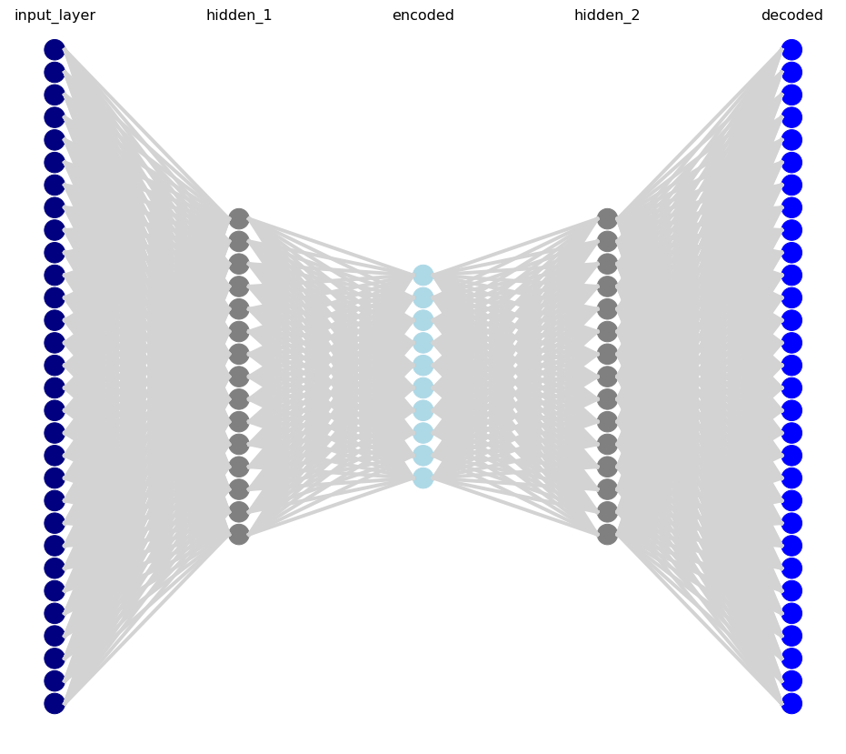

[output not shown]

```python
import nnv
import matplotlib.pyplot as plt
plt.rcParams["figure.figsize"] = (20, 15)

layers = [
    {"title":"input_layer", "units": 30, "color": "navy"},
    {"title":"hidden_1", "units": 15},
    {"title":"encoded", "units": 10, "color": "lightBlue"},
    {"title":"hidden_2", "units": 15},
    {"title":"decoded", "units": 30, "color": "blue"},
]

nnv.NNV(layers, max_num_nodes_visible=30,
        node_radius=5, spacing_layer=80, font_size=16)\
    .render()
```

```python
from keras.layers import Input, Dense
from keras.models import Model

input_layer = Input(shape=(30, ))
hidden_1 = Dense(15, activation="tanh")(input_layer)
encoded = Dense(10, activation="tanh")(hidden_1)
hidden_2 = Dense(15, activation="tanh")(encoded)
decoded = Dense(30, activation="sigmoid")(hidden_2)
autoencoder = Model(input_layer, decoded)
```

[output not shown]

```python
autoencoder.compile(optimizer="adam",
                    loss="mean_squared_error")
```

[output not shown]

```python
from sklearn.model_selection import train_test_split

X_train, X_test = train_test_split(X_nonfraud, test_size=0.25,
                                   random_state=2019)
```

```python
autoencoder.fit(X_train, X_train,
                epochs=100,
                batch_size=128,
                shuffle=True,
                validation_data=(X_test, X_test))
```

[output not shown]

```
Train on 213236 samples, validate on 71079 samples
```

```
<keras.callbacks.History at 0x7f01fc0f7a90>
```

## Loss function values comparison

As said, the value of the loss function is an indicator of how well our autoencoder was able to recreate given input. We can easily check how the values differ between train, test and fraud datasets.

```python
from keras.losses import mean_squared_error
from keras import backend as K

mse_train = K.eval(mean_squared_error(X_train,
                                      autoencoder.predict(X_train)))
```

```python
mse_test = K.eval(mean_squared_error(X_test,
                                     autoencoder.predict(X_test)))
```

```python
mse_fraud = K.eval(mean_squared_error(X_fraud,
                                      autoencoder.predict(X_fraud)))
```

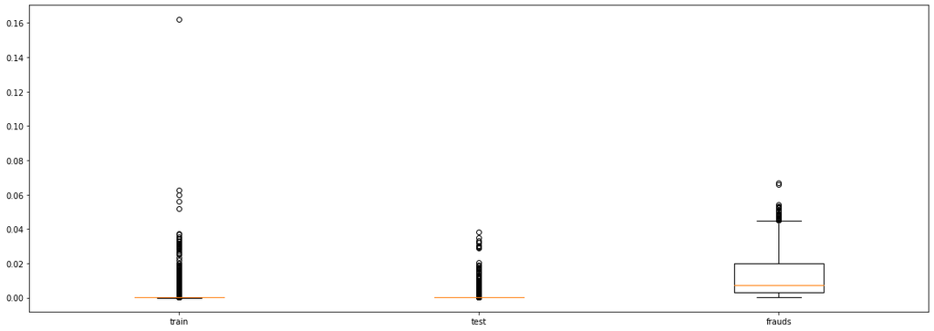

```python
plt.rcParams["figure.figsize"] = (20, 7)

plt.boxplot([mse_train, mse_test, mse_fraud],
            labels=["train", "test", "frauds"])
plt.show()
```